# HW3.Rmd

For this assignment will be analyzing data on the Vegetation and Environment in Dutch Dune Meadows.

To import the data and read the metadata run the following:

```r
library(vegan)
data(dune)
data(dune.env)
?dune
```

# The data dune is already structured as a community matrix, dervied from the dune.env data set

```r
dune_mds <- metaMDS(dune)
```

```
## *** Solution reached
```

#might need to recode moisture as a numeric value

1. Conduct an indirect ordination on the dune plant community. Specifically, visually examine a NMDS plot using the bray-curtis distance metric. Below is some code to help you develop a potential plot that emphasizes the role of the environmental variable “Moisture”. Describe how you interpret the graphic. What is the goal of creating such a plot? Does this analysis suggest any interesting findings with respect to the dune vegetation?

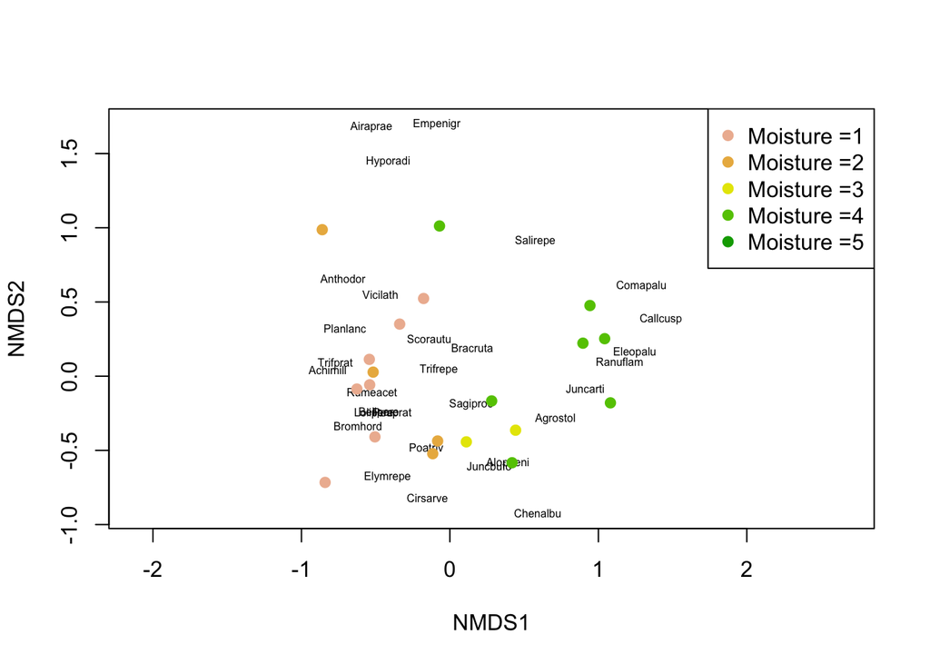

   ```r
   plot(dune_mds, type='n')
   text(dune_mds, 'sp', cex=.5)
   # generate vector of colors
   color_vect = rev(terrain.colors(6))[-1]
   points(dune_mds, 'sites', pch=19,
          col=color_vect[dune.env$Moisture])
   legend('topright', paste("Moisture =", 1:5, sep=''),
          col=color_vect, pch=19)
   ```

   # The above graph shows the moisture levels different species live in. The plot is a very basic summary of the data, showing that the dune vegetation can grow in varying levels of moisture and that the plants that have the same moisture level seem to live in the similar sites.
2. Carry out a direct ordination using CCA in order to test any potential hypotheses that you developed after examining the MDS plot. Specifically, carry out a test of the entire model (i.e., including all constrained axes) and also carry out tests at the scale of individual explanatory variables you included in your model if you included more than one variable. Plot your results.

```r
dune.env$Moisture <- as.numeric(dune.env$Moisture)
cca_veg <- cca(dune ~ ., data= dune.env)
RsquareAdj(cca_veg, 100)
```

```
## $r.squared
## [1] 0.6333044
##
## $adj.r.squared
## [1] 0.2286688
```

```r
anova(cca_veg, permutations = 999)
```

```
## Permutation test for cca under reduced model
## Permutation: free
## Number of permutations: 999
##
## Model: cca(formula = dune ~ A1 + Moisture + Management + Use + Manure, data = dune.env)
##          Df ChiSquare      F Pr(>F)
## Model    10   1.33961 1.5544  0.006 **
## Residual  9   0.77566
## ---
## Signif. codes:  0 '***' 0.001 '**' 0.01 '*' 0.05 '.' 0.1 ' ' 1
```

```r
anova(cca_veg, by='margin', permutations = 999)
```

```
## Permutation test for cca under reduced model
## Marginal effects of terms
## Permutation: free
## Number of permutations: 999
##
## Model: cca(formula = dune ~ A1 + Moisture + Management + Use + Manure, data = dune.env)
##            Df ChiSquare      F Pr(>F)
## A1          1   0.10731 1.2451  0.230
## Moisture    1   0.15232 1.7673  0.058 .
## Management  2   0.16757 0.9721  0.492
## Use         2   0.13818 0.8017  0.705
## Manure      3   0.21752 0.8413  0.708
## Residual    9   0.77566
## ---
## Signif. codes:  0 '***' 0.001 '**' 0.01 '*' 0.05 '.' 0.1 ' ' 1
```

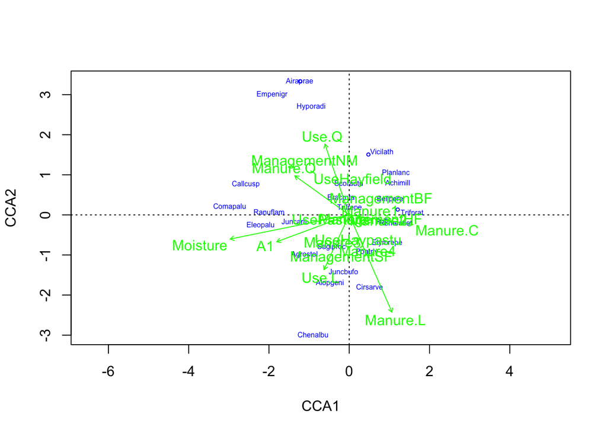

```r
plot(cca_veg, type='n', scaling=1)
orditorp(cca_veg, display='sp', cex=0.5, scaling=1, col='blue')
text(cca_veg, display='cn', col='green')
```

```r
anova(cca_veg, by='margin', permutations = 999)
```

```
## Permutation test for cca under reduced model
## Marginal effects of terms
## Permutation: free
## Number of permutations: 999
##
## Model: cca(formula = dune ~ A1 + Moisture + Management + Use + Manure, data = dune.env)
##            Df ChiSquare      F Pr(>F)
## A1          1   0.10731 1.2451  0.242
## Moisture    1   0.15232 1.7673  0.067 .
## Management  2   0.16757 0.9721  0.505
## Use         2   0.13818 0.8017  0.687
## Manure      3   0.21752 0.8413  0.709
## Residual    9   0.77566
## ---
## Signif. codes:  0 '***' 0.001 '**' 0.01 '*' 0.05 '.' 0.1 ' ' 1
```

3. Do your two analyses agree with one another or complement one another or do these two analyses seem to be suggesting different take home messages? Which analysis do you find to be more useful?

#The two analyses do seem to compliment each other. The cca shows that moisture is linear in its effect, which seems to compliment the indirect ordination. The indirect ordination shows that moisture is related to site of the plants, and in that way a similarly linear relationship.